#### 01/2024

#### Máster de Ciencia de Datos de la UOC

# Lectura, limpieza, análisis exploratorio y creación del dataset del primer ciclo

Este conjunto de notebooks han sido construidos a lo largo de todo el proceso del desarollo, iterando y añadiendo mejoras durante todo el proceso. Para que fuera más manejable todo el proyecto, se ha estructurado de esta forma para que no se tuviera que ejecutar todo cada vez, definiendo un conjunto de fases estructuradas en los notebooks.

Los tres primeros notebooks representan el primer ciclo, en el cual se recoge un subconjunto de atributos y se desarrolla todo el ciclo del dato desde la limpieza hasta la obtención del mejor modelo. Se ha querido proceder de esta forma para enfocar los esfuerzos en cada paso, sin perder la noción de los objetivos por querer abarcar todas las posibilidades en la primera etapa. Estos tres notebooks son los que asientan las bases de todos los pasos, por lo que se obtienen:

1. Lectura de los datos, limpieza, análisis exploratorio y creación del primer dataset.
2. Estudio de técnicas para tratar el conjunto de datos desbalanceados.
3. Estudio de modelos: Conjunto de datos del primer ciclo.

Posteriores notebooks enriquecen el conjunto de datos con nuevos atributos y exploran cómo afecta en el modelo final.

1. Mejoras en el dataset.
2. Estudio Modelos: Conjunto de datos refinado.

Se utiliza pyspark para la lectura y manipulación de los datasets por facilidad en su uso, ya que es el que suelo utilizar diariamente en mi entorno laboral, por lo que en cada notebook se inicia una sesión de spark para poder utilizarlo.

## Índice

- Lectura de archivos y limpieza de tipos
- Limpieza de dataframes y exploración del dato
  - Usuarios
  - Consumos y sesiones
- Consolidación
  - Agrupación de datos
  - Feature engineering
- Preparación del dataset
  - One-hot-encoding
  - Tests estadísticos

## Lectura de archivos y limpieza de tipos

```python
from pyspark.sql import SparkSession

# inicio sesion de spark
spark = SparkSession.builder.appName('Read Files').getOrCreate()
```

Se hace una lectura de todos los ficheros disponibles aunque no se utilicen todos.

```python
from pyspark.sql.functions import *
from pyspark.sql.types import *
from pyspark.sql.window import Window
import seaborn as sns
import matplotlib.pyplot as plt
import pandas as pd

consumos = spark.read.option("header","true")\
           .option("multiline",True)\
           .option("inferSchema",True)\
           .option("delimiter",";")\
           .option("dateFormat","d/M/yyyy H:mm:ss")\
           .option("charset","iso-8859-1")\
           .csv('Archivos/Linea1-Consumos.txt')

# está incluida en el dataframe de consumos
empresas_consultadas = spark.read.option("header","true")\
           .option("multiline",True)\
           .option("inferSchema",True)\
           .option("delimiter",";")\
           .option("dateFormat","d/M/yyyy H:mm:ss")\
           .option("charset","iso-8859-1")\
           .csv('Archivos/Linea1-Empresas_Consultadas.txt')

primer_consumo = spark.read.option("header","true")\
           .option("multiline",True)\
           .option("inferSchema",True)\
           .option("delimiter",";")\
           .option("dateFormat","d/M/yyyy H:mm:ss")\
           .option("charset","iso-8859-1")\
           .csv('Archivos/Linea1-Primer_Consumo.txt')

sesiones = spark.read.option("header","true")\
           .option("multiline",True)\
           .option("inferSchema",True)\
           .option("delimiter",";")\
           .option("dateFormat","d/M/yyyy H:mm:ss")\
           .option("charset","iso-8859-1")\
           .csv('Archivos/Linea1-Sesiones.txt')

usuarios = spark.read.option("header","true")\
           .option("multiline",True)\
           .option("inferSchema",True)\
           .option("delimiter",";")\
           .option("dateFormat","d/M/yyyy H:mm:ss")\
           .option("charset","iso-8859-1")\
           .csv('Archivos/Linea1-Usuarios.txt')

ventas = spark.read.option("header","true")\
           .option("multiline",True)\
           .option("inferSchema",True)\
           .option("delimiter",";")\
           .option("dateFormat","d/M/yyyy H:mm:ss")\
           .option("charset","iso-8859-1")\
           .csv('Archivos/Linea1-Ventas.txt')
```

Se han añadido diferentes opciones en la lectura para que fuera lo más correcta posible. Se ha utilizado la iso-8859-1 para que los carácteres del castellano pudieran codificarse bien. Por otro lado, se ha utilizado un formato de fecha directamente en la lectura para no tener complicaciones con el tipo.

Se comprueban todos los tipos de las columnas de cada dataset para verificar que la inferencia de los tipos ha sido correcta. Se puede conseguir con printSchema() como se puede leer a continuación con el dataset de ventas. Se han eliminado las consultas de los demás datasets para no alargar demasiado el notebook.

```python
ventas.printSchema()
```

```
root
 |-- IDVENTA: string (nullable = true)
 |-- ID_USUARIO: string (nullable = true)
 |-- FECHAVENTA: date (nullable = true)
 |-- TIPOVENTA: string (nullable = true)
 |-- IMPORTE: integer (nullable = true)
 |-- NUMVENTAS: integer (nullable = true)
 |-- IMPORTES: string (nullable = true)
 |-- VP Informe: integer (nullable = true)
 |-- BONO: integer (nullable = true)
 |-- SUSCRIPCION: integer (nullable = true)
 |-- VP Listado: integer (nullable = true)
```

```python
ventas.limit(5).toPandas()
```

|  | IDVENTA | ID_USUARIO | FECHAVENTA | TIPOVENTA | IMPORTE | NUMVENTAS | IMPORTES | VP Informe | BONO | SUSCRIPCION | VP Listado |
| --- | --- | --- | --- | --- | --- | --- | --- | --- | --- | --- | --- |
| 0 | 40069190,00 | 6869761,00 | 2018-01-02 | VP Informe | 35000 | 1 | 35000,00 | 1.0 | NaN | NaN | NaN |
| 1 | 40071981,00 | 6869989,00 | 2018-01-02 | VP Informe | 15000 | 1 | 15000,00 | 1.0 | NaN | NaN | NaN |
| 2 | 40078934,00 | 6869802,00 | 2018-01-03 | VP Listado | 1070503 | 1 | 1070503,00 | NaN | NaN | NaN | 1.0 |
| 3 | 40090106,00 | 6872111,00 | 2018-01-04 | VP Informe | 25000 | 1 | 25000,00 | 1.0 | NaN | NaN | NaN |
| 4 | 40111415,00 | 6873222,00 | 2018-01-05 | VP Informe | 15000 | 1 | 15000,00 | 1.0 | NaN | NaN | NaN |

Se detecta que las columnas de Id tienen una terminación ",00" incorrecta, seguramente debido a cómo se han exportado los datos desde la base de datos del ecommerce. Aunque como cada Id tiene que ser único y todos los valores siguen el mismo patrón, esta terminación es inocua en la posible relación con joins, pero es buena práctica limpiar estos atributos para que sean numeraciones bien estructuradas.

Por otro lado, se comprueba que en ventas la columna de IMPORTES es un string debido a que la coma realmente tendría que estar como un punto para que fuera un decimal.

Finalmente, hay atributos que se han inferenciado como entero (integer) aunque a priori sólo tienen valores de 0 y 1 (booleanos), por lo que para el primer ciclo, se transforman a carácter y se volverán a transformar si fuera necesario.

Para arreglar todos estos campos, se crean tres funciones que limpiarán cada columna y las dejarán en el formato adecuado:

```python
def columns2clean(dataframe, columns):
    for colname in columns:
        dataframe = dataframe.withColumn(colname, regexp_replace(colname, ',00', ''))
    return dataframe

def columns2double(dataframe, columns):
    for colname in columns:
        dataframe = dataframe.withColumn(colname, regexp_replace(colname, ',', '.'))
        dataframe = dataframe.withColumn(colname, col(colname).cast(DoubleType()))
    return dataframe

def columns2string(dataframe, columns):
    for colname in columns:
        dataframe = dataframe.withColumn(colname, col(colname).cast(StringType()))
    return dataframe
```

Se aplican las funciones:

```python
consumos = columns2clean(consumos, ["IDCONSUMO","IDUSUARIO","IDPRODUCTO","EMPCONSUL_ID"])
empresas_consultadas = columns2clean(empresas_consultadas, ["EMPCONSUL_ID"])
primer_consumo = columns2clean(primer_consumo, ["IDCONSUMO","IDUSUARIO","IDPRODUCTO","EMPCONSUL_ID"])
sesiones = columns2clean(sesiones, ["IDUSUARIO"])
usuarios = columns2clean(usuarios, ["IDUSUARIO"])
usuarios = columns2string(usuarios, ["CANAL_REGISTRO","IND_CLIENTE","BONDAD_EMAIL"])
ventas = columns2clean(ventas, ["IDVENTA","ID_USUARIO"])
ventas = columns2double(ventas, ["IMPORTE","IMPORTES"])
ventas = columns2string(ventas, ["VP Informe","BONO", "SUSCRIPCION", "VP Listado"])
```

Comprobación:

```python
ventas.limit(5).toPandas()
```

|  | IDVENTA | ID_USUARIO | FECHAVENTA | TIPOVENTA | IMPORTE | NUMVENTAS | IMPORTES | VP Informe | BONO | SUSCRIPCION | VP Listado |
| --- | --- | --- | --- | --- | --- | --- | --- | --- | --- | --- | --- |
| 0 | 40069190 | 6869761 | 2018-01-02 | VP Informe | 35000.0 | 1 | 35000.0 | 1 | None | None | None |
| 1 | 40071981 | 6869989 | 2018-01-02 | VP Informe | 15000.0 | 1 | 15000.0 | 1 | None | None | None |
| 2 | 40078934 | 6869802 | 2018-01-03 | VP Listado | 1070503.0 | 1 | 1070503.0 | None | None | None | 1 |
| 3 | 40090106 | 6872111 | 2018-01-04 | VP Informe | 25000.0 | 1 | 25000.0 | 1 | None | None | None |
| 4 | 40111415 | 6873222 | 2018-01-05 | VP Informe | 15000.0 | 1 | 15000.0 | 1 | None | None | None |

## Limpieza de dataframes y exploración del dato

Una vez se tienen los dataframes con los tipos correctos, se eligen los dataframes de usuarios, consumos y sesiones para la exploración de los datos y la creación del primer dataset. Esto se debe a un estudio preliminar de cada archivo, ya que se va a querer predecir los clientes potenciales, por lo que el dataframe de usuarios será el dataframe principal y se enriquecerá con atributos de las tablas de consumos y sesiones.

Ventas quedará excluido de este estudio, ya que se quiere identificar los clientes respecto a todos los usuarios, y en ventas únicamente están los que ya han comprado. La tabla de primer_consumo no se utiliza en este ciclo, pero podría ser interesante explorar si es relevante el primer consumo de cada usuario. La tabla de empresas_consultadas es un subconjunto de atributos de la tabla de consumos, por lo que se descarta de este estudio ya que esa información ya se tiene en un dataframe que se utiliza.

### Usuarios

Se explora la tabla de usuarios:

```python
usuarios.limit(5).toPandas()
```

|  | IDUSUARIO | TIPOUSUARIO | FEC_REGISTRO | CANAL_REGISTRO | IND_CLIENTE | BONDAD_EMAIL | USU_TIPO | FEC_CLIENTE |
| --- | --- | --- | --- | --- | --- | --- | --- | --- |
| 0 | 7668403 | PF | 2019-03-14 | 3 | 0 | 20 | None | None |
| 1 | 7667922 | PF | 2019-03-14 | 2 | 0 | 20 | None | None |
| 2 | 7721206 | PJ | 2019-04-10 | 4 | 0 | 20 | None | None |
| 3 | 7667953 | PJ | 2019-03-14 | 3 | 0 | 20 | EMPRESARIO INDIVIDUAL | None |
| 4 | 7667971 | PJ | 2019-03-14 | 3 | 0 | 20 | SOCIEDAD COMERCIAL/INDUSTRIAL | None |

Se comprueba la proporción entre los clientes y los no clientes a modo informativo antes de proceder al estudio de los nulos,

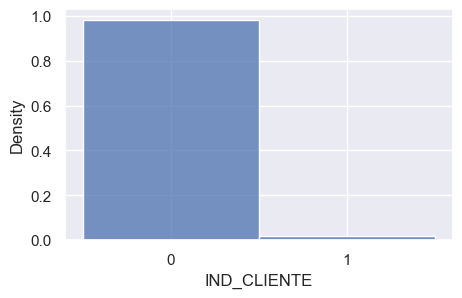

```python
plt.figure(figsize=(5,3))
sns.set(style='darkgrid')
sns.histplot(data=usuarios.toPandas(),x="IND_CLIENTE", stat="density")
plt.show()
```

Se comprueba que los datos estan muy desbalanceados hacia los usuarios que nunca han comprado. Este sesgo se tendrá que tratar en posteriores etapas para poder predecir eficientemente los potenciales clientes. Se identifica la gran importancia de la ciencia de datos para centrar los recursos en únicamente un pequeño porcentaje de toda la población.

Seguidamente, se procede al estudio de los nulos del dataframe a través de info():

```python
usuarios.toPandas().info(memory_usage=False)
```

```
<class 'pandas.core.frame.DataFrame'>
RangeIndex: 142736 entries, 0 to 142735
Data columns (total 8 columns):
 #   Column          Non-Null Count   Dtype
---  ------          --------------   -----
 0   IDUSUARIO       142736 non-null  object
 1   TIPOUSUARIO     142736 non-null  object
 2   FEC_REGISTRO    142736 non-null  object
 3   CANAL_REGISTRO  139215 non-null  object
 4   IND_CLIENTE     142736 non-null  object
 5   BONDAD_EMAIL    142736 non-null  object
 6   USU_TIPO        33308 non-null   object
 7   FEC_CLIENTE     2609 non-null    object
dtypes: object(8)
```

Se tienen nulos en los atributos CANAL_REGISTRO, USU_TIPO y FEC_CLIENTE. El atributo de la fecha de cliente es completamente normal que tenga nulos, ya que esta fecha es no nula únicamente cuando IND_CLIENTE es 1.

Se comprueba cada atributo por separado para saber cómo tratar los nulos. Primeramente, se analiza si todos los usuarios o usuarias con IND_CLIENTE = 1 tienen FEC_CLIENTE, para ello, se crea una agregación que identifique visualmente esta problemática.

```python
usuarios.withColumn("haveFecCliente", when(col("FEC_CLIENTE").isNotNull(), 1).otherwise(0))\
        .groupBy("IND_CLIENTE","haveFecCliente").count().toPandas()
```

|  | IND_CLIENTE | haveFecCliente | count |
| --- | --- | --- | --- |
| 0 | 1 | 0 | 6 |
| 1 | 0 | 0 | 140121 |
| 2 | 1 | 1 | 2609 |

Estos resultados reflejan que los datos no estan completamente limpios. Se tienen 2615 usuarios que han comprado alguna vez pero 6 de ellos no tienen la fecha en la que se convirtieron a cliente.

```python
usuarios.where("IND_CLIENTE == '1' and FEC_CLIENTE is null").toPandas()
```

|  | IDUSUARIO | TIPOUSUARIO | FEC_REGISTRO | CANAL_REGISTRO | IND_CLIENTE | BONDAD_EMAIL | USU_TIPO | FEC_CLIENTE |
| --- | --- | --- | --- | --- | --- | --- | --- | --- |
| 0 | 7880345 | PF | 2019-07-08 | 1 | 1 | 20 | None | None |
| 1 | 7867996 | PF | 2019-07-02 | 1 | 1 | 9 | None | None |
| 2 | 7872518 | PJ | 2019-07-04 | 1 | 1 | 20 | EMPRESARIO INDIVIDUAL | None |
| 3 | 7533849 | PJ | 2019-01-09 | 1 | 1 | 20 | None | None |
| 4 | 8231610 | PF | 2019-12-18 | 1 | 1 | 20 | None | None |
| 5 | 8240404 | PF | 2019-12-23 | 3 | 1 | 20 | None | None |

Como son sólo 6 que no tienen la fecha que se utilizará para hacer feature engineering, se mira primero si en ventas se tiene esa información de los usuarios para traerla a partir de su identificador:

```python
ventas.where("ID_USUARIO IN ('7880345','7867996','7872518','7533849','8231610','8240404')").toPandas()
```

|  | IDVENTA | ID_USUARIO | FECHAVENTA | TIPOVENTA | IMPORTE | NUMVENTAS | IMPORTES | VP Informe | BONO | SUSCRIPCION | VP Listado |
| --- | --- | --- | --- | --- | --- | --- | --- | --- | --- | --- | --- |

Se comprueba que estos usuarios no están, al ser 6 de 2609 (un 0.2% de los clientes), se eliminan estos registros:

```python
usuarios = usuarios.where("!(IND_CLIENTE == '1' and FEC_CLIENTE is null)")
usuarios.withColumn("haveFecCliente", when(col("FEC_CLIENTE").isNotNull(), 1).otherwise(0))\
        .groupBy("IND_CLIENTE","haveFecCliente").count().toPandas()
```

|  | IND_CLIENTE | haveFecCliente | count |
| --- | --- | --- | --- |
| 0 | 0 | 0 | 140121 |
| 1 | 1 | 1 | 2609 |

Si se analiza la columna USU_TIPO, se ve una gran cantidad de nulos. Este atributo se descartaria directamente por tener tal porcentaje de nulos, pero se explora un conteo de los valores informados para la variable target (IND_CLIENTE) por si hubiera una mayor proporción de valores para los clientes.

```python
usuarios.withColumn("haveUSU_TIPO", when(col("USU_TIPO").isNotNull(),1).otherwise(0))\
        .groupBy("IND_CLIENTE","haveUSU_TIPO").count().toPandas()
```

|  | IND_CLIENTE | haveUSU_TIPO | count |
| --- | --- | --- | --- |
| 0 | 1 | 0 | 1347 |
| 1 | 0 | 0 | 108076 |
| 2 | 1 | 1 | 1262 |
| 3 | 0 | 1 | 32045 |

Alrededor de la mitad de los clientes tienen el valor informado y la otra mitad no, por lo que no es informativo a priori. No se añadirá al estudio.

Finalmente la variable CANAL_REGISTRO, esta variable el porcentaje de nulos es de un 2.5% para el conjunto total, por lo que se procederá a substituir los nulos por el valor más recurrente para los clientes por un lado, y para los no clientes por otro. De esta forma la categoria más recurrente en los no clientes, al ser más numerosos, no afectará a los clientes.

La categoría por subgrupos:

```python
# se substituyen los nulos por el valor más frecuente:

usuarios = usuarios.withColumn("CANAL_REGISTRO", when(col("CANAL_REGISTRO").isNull() & (col("IND_CLIENTE") == '1'),\
                                                      lit("1")).otherwise(col("CANAL_REGISTRO")))
usuarios = usuarios.withColumn("CANAL_REGISTRO", when(col("CANAL_REGISTRO").isNull() & (col("IND_CLIENTE") == '0'),\
                                                      lit("3")).otherwise(col("CANAL_REGISTRO")))
```

Una vez no se tienen nulos, se va a proceder a una simplificación en la variable categórica "BONDAD_EMAIL", de forma que refleje únicamente si un correo es correcto o si no tiene o es invalido (no correcto), obteniendo un nuevo atributo dicotómico.

```python
usuarios = usuarios.withColumn("BONDAD_EMAIL_SIMP", when(col("BONDAD_EMAIL") == "20",lit('1')).otherwise('0'))
```

Se exploran los usuarios y usuarias por subgrupos:

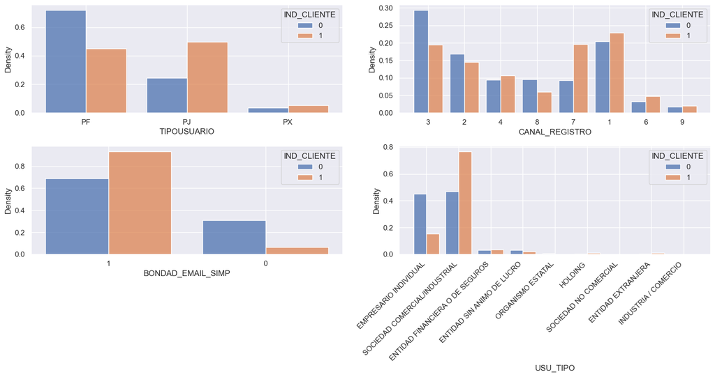

```python
target = "IND_CLIENTE"

fig, axs = plt.subplots(2,2,figsize=(15,8))
sns.set(style='darkgrid')
sns.histplot(data=usuarios.toPandas(),x="TIPOUSUARIO", stat="density",hue=target, ax=axs[0,0],
             common_norm=False, multiple="dodge", shrink = 0.8)
sns.histplot(data=usuarios.toPandas(),x="CANAL_REGISTRO", stat="density",hue=target, ax=axs[0,1],
             common_norm=False, multiple="dodge", shrink = 0.8)
sns.histplot(data=usuarios.toPandas(),x="BONDAD_EMAIL_SIMP", stat="density",hue=target, ax=axs[1,0],
             common_norm=False, multiple="dodge", shrink = 0.8)
sns.histplot(data=usuarios.toPandas(),x="USU_TIPO", stat="density",hue=target, ax=axs[1,1],
             common_norm=False, multiple="dodge", shrink = 0.8)
# se cambia unicamente la rotacion del USU_TIPO
plt.sca(axs[1, 1])
plt.xticks(rotation=45, horizontalalignment="right")
plt.tight_layout()
plt.show()
```

A través de los cuatro gráficos se pueden describir las dos poblaciones. En el primer gráfico en la esquina superior izquierda se representa la distribución entre si el usuario se ha clasificado como persona física o jurídica (además de PX que representaba la tipologia de usuario no definida). Se observa que las personas jurídicas, es decir, usuarios en nombre de empresas, tienen una tendencia a comprar más que la población de personas físicas. Este resultado puede deberse a que las personas jurídicas pueden tener un mayor financiamiento para comprar productos de diferentes webs o que tengan más definido el objetivo de su navegación en la plataforma. En cambio, las personas físicas pueden no tener esa fuerza de compra entre otras razones.

Para la variable CANAL_REGISTRO no se aplica a priori una agrupación de directorios populares y de directorios especializados. Esto se debe a que, por ejemplo, los números 2, 3 y 7 representan directorios populares, donde para los directorios 2 y 3 hay una mayor proporción de no clientes, mientras que en el 7 es el caso contrario. Si se aplicara una agrupación de este estilo, que puede parecer intuitiva, se podría atenuar esta diferencia entre subgrupos, por lo que se mantiene la separación.

En el caso del atributo agregado de BONDAD_EMAIL_SIMP, sí que se encuentran diferencias significativas entre las dos poblaciones. Los clientes tienen una mayor tendencia a registrar su correo de forma correcta debido a que seguramente tienen una mayor predisposición a confiar con el ecommerce por estar interesados en los productos que ofrecen, mientras que los que nunca comprarán pueden no estar tan dispuestos a distribuir esa información.

Finalmente, aunque el atributo USU_TIPO queda descartado por tener una gran cantidad de nulos, se observa que, para los usuarios que sí que hay datos hay una mayor predisposición a convertirse en clientes si estos pertenecen a una sociedad comercial o industrial, en comparación a si es un empresario individual, donde la distribución es al contrario. Estos resultados podrían relacionarse con el primer gráfico entre persona jurídica y física, aunque no se pueden deducir más conclusiones debido a la falta de datos en la tabla.

Finalmente, se muestra el dataframe:

```python
usuarios.limit(3).toPandas()
```

|  | IDUSUARIO | TIPOUSUARIO | FEC_REGISTRO | CANAL_REGISTRO | IND_CLIENTE | BONDAD_EMAIL | USU_TIPO | FEC_CLIENTE | BONDAD_EMAIL_SIMP |
| --- | --- | --- | --- | --- | --- | --- | --- | --- | --- |
| 0 | 7668403 | PF | 2019-03-14 | 3 | 0 | 20 | None | None | 1 |
| 1 | 7667922 | PF | 2019-03-14 | 2 | 0 | 20 | None | None | 1 |
| 2 | 7721206 | PJ | 2019-04-10 | 4 | 0 | 20 | None | None | 1 |

Se guarda el dataframe de usuarios limpio para poder usarlo en posteriores ciclos.

```python
usuarios.toPandas().to_parquet("/Archivos/usuariosPostLimpieza.parquet")
```

### Consumos y sesiones

Se exploran los registros de consumos:

```python
consumos.toPandas().info(memory_usage=False)
```

```
<class 'pandas.core.frame.DataFrame'>
RangeIndex: 571498 entries, 0 to 571497
Data columns (total 11 columns):
 #   Column                Non-Null Count   Dtype
---  ------                --------------   -----
 0   IDCONSUMO             571498 non-null  object
 1   IDUSUARIO             571498 non-null  object
 2   IDPRODUCTO            571498 non-null  object
 3   DESCPRODUCTO          571498 non-null  object
 4   FECHACONSUMO          571498 non-null  object
 5   EMPCONSUL_ID          571498 non-null  object
 6   EMPCONSUL_SECTOR      568593 non-null  object
 7   EMPCONSUL_DESCSECTOR  568593 non-null  object
 8   EMPCONSUL_PROV_DESC   568599 non-null  object
 9   NumConsumos           571498 non-null  int32
 10  NumUsuarios           571498 non-null  int32
dtypes: int32(2), object(9)
```

Se observa que de la tabla de consumos, únicamente información respecto a las empresas consultadas tiene nulos. Estos nulos representan a un 0.5% de los datos, por lo que se procede a eliminarlos.

```python
consumos = consumos.na.drop()
consumos.toPandas().info(memory_usage=False)
```

```
<class 'pandas.core.frame.DataFrame'>
RangeIndex: 568573 entries, 0 to 568572
Data columns (total 11 columns):
 #   Column                Non-Null Count   Dtype
---  ------                --------------   -----
 0   IDCONSUMO             568573 non-null  object
 1   IDUSUARIO             568573 non-null  object
 2   IDPRODUCTO            568573 non-null  object
 3   DESCPRODUCTO          568573 non-null  object
 4   FECHACONSUMO          568573 non-null  object
 5   EMPCONSUL_ID          568573 non-null  object
 6   EMPCONSUL_SECTOR      568573 non-null  object
 7   EMPCONSUL_DESCSECTOR  568573 non-null  object
 8   EMPCONSUL_PROV_DESC   568573 non-null  object
 9   NumConsumos           568573 non-null  int32
 10  NumUsuarios           568573 non-null  int32
dtypes: int32(2), object(9)
```

Se guarda el dataframe de consumos limpio para poder usarlo en posteriores ciclos.

```python
consumos.toPandas().to_parquet("/Archivos/consumosPostLimpieza.parquet")
```

Se explora la entidad sesiones:

```python
sesiones.toPandas().info(memory_usage=False)
```

```
<class 'pandas.core.frame.DataFrame'>
RangeIndex: 182054 entries, 0 to 182053
Data columns (total 3 columns):
 #   Column        Non-Null Count   Dtype
---  ------        --------------   -----
 0   IDUSUARIO     182054 non-null  object
 1   FECHA_SESION  182054 non-null  object
 2   SESIONES      182054 non-null  int32
dtypes: int32(1), object(2)
```

No existen nulos, se comprueba si existen outliers con los subgrupos de la variable target. Para ello, se aplica un join para traer la variable IND_CLIENTE de la tabla de usuarios y se visualiza con un diagrama de cajas.

```python
sesiones.limit(5).toPandas()
```

|  | IDUSUARIO | FECHA_SESION | SESIONES |
| --- | --- | --- | --- |
| 0 | 6868841 | 2018-01-01 | 12 |
| 1 | 6868844 | 2018-01-01 | 4 |
| 2 | 6868850 | 2018-01-01 | 4 |
| 3 | 6868859 | 2018-01-01 | 3 |
| 4 | 6868859 | 2018-07-09 | 1 |

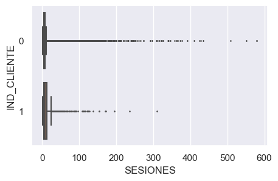

```python
sesiones = sesiones.join(usuarios, "IDUSUARIO", "left").select("IDUSUARIO","FECHA_SESION","SESIONES","IND_CLIENTE")

plt.figure(figsize=(5,3))
sns.boxplot(data=sesiones.toPandas(), x="SESIONES", y="IND_CLIENTE", flierprops = dict(markersize = 1))
plt.show()
```

Como se puede comprobar, se tienen outliers en los dos subgrupos, aunque en el subgrupo de clientes se tienen menos outliers y llegan a un menor número de sesiones. Una explicación plausible es que se trate de webscrapping de algún tipo. Con los datos que proporciona la empresa podría ser perfectamente posible que se utilice técnicas de webscrapping para recoger datos de forma automática, ya que un número tan elevado de sesiones en un dia no sería natural en el comportamiento de un usuario. De hecho, el segmento entre el primer y tercer cuartil, junto con los bigotes del diagrama de cajas, demuestra un comportamiento más natural en el número de sesiones diarias. Este argumento también podría explicar el por qué el subgrupo de no clientes tiene outliers más alejados del tercer cuartil.

Para solucionar esta casuística, se crea una función generalista que recoja un dataframe y calcule los valores de los bigotes y transforme la columna objetivo, de forma que todos los outliers de cada subgrupo queden en el máximo definido por el bigote positivo.

```python
def outliersToMaxWhisker(data, columnName):
    """Esta función busca los valores de los bigotes de una variable numérica a partir de los subgrupos
       definidos por la variable target y devuelve el dataframe transformado
       Q1C se refiere al valor del primer cuartil para el subgrupo de clientes.
       Q1nc se refiere a los no clientes."""

    Q1C, Q3C = data.where("IND_CLIENTE == '1'").approxQuantile(columnName, [0.25, 0.75], 0)
    Q1nC, Q3nC = data.where("IND_CLIENTE == '0'").approxQuantile(columnName, [0.25, 0.75], 0)

    whiskerC = np.floor(Q3C + 1.5*(Q3C-Q1C))
    whiskernC = np.floor(Q3nC + 1.5*(Q3nC-Q1nC))

    data = data.withColumn(columnName, when((col(columnName) > whiskerC) &
                                            (col("IND_CLIENTE") == '1'),\
                                            lit(whiskerC)).otherwise(col(columnName)))
    data = data.withColumn(columnName, when((col(columnName) > whiskernC) &
                                            (col("IND_CLIENTE") == '0'),\
                                            lit(whiskernC)).otherwise(col(columnName)))
    return data
```

Se aplica la función y se visualiza el dato transformado:

```python
sesiones = outliersToMaxWhisker(sesiones, "SESIONES")
```

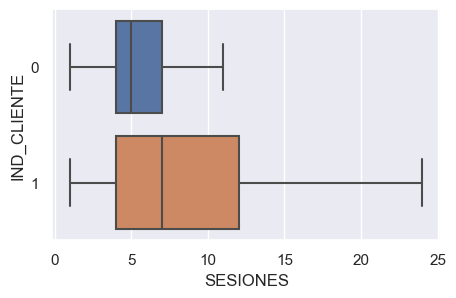

```python
plt.figure(figsize=(5,3))
sns.boxplot(data=sesiones.toPandas(), x="SESIONES", y="IND_CLIENTE", showfliers = True)
plt.show()
```

Ya no se tienen outliers, para aquellos usuarios que acaban transformándose en clientes, al estar más interesados en los productos que oferta el ecommerce, tienen un mayor número de sesiones.

## Consolidación

### Agrupación de datos

Una vez que ya se tienen las entidades que se van a utilizar libres de nulos y outliers, se procede a hacer una primera consolidación de los datos.

Para ello, como se ha dicho anteriormente, la entidad principal será usuarios, en la que se introducirán joins para traer variables de otras entidades. De Consumos inicialmente sólo se hará una agregación: Cuántas veces ha consumido un usuario antes de transformarse a cliente. Posteriormente se jugará con otras variables como cuántos consumos han sido de Ficha básica o promocional o qué tipo de empresas ha consumido.

Se crea una primera agregación, para cada usuario se obtiene la última fecha con consumo y el número total de consumos. La última fecha de consumo se obtiene para comprobar que no hay consumos posteriores a la fecha que el usuario se hizo cliente, ya que si no se tendría que hacer algún tratamiento adicional.

Como inciso, como se ha hecho un tratamiento de outliers para las sesiones, al crear una nueva variable con el número total de consumos, también pueden afectar aquellos usuarios tipo webscrapping, ya que consumen muchos productos gratuitos, por lo que se hace la suma total de consumos y luego todos los outliers de esta nueva variable se fijarán en el máximo del bigote.

```python
consumosAgregacion = consumos.groupBy("IDUSUARIO").agg(max("FECHACONSUMO").alias("maxFechaConsumo"),
                                                       count("IDCONSUMO").alias("numConsumos"))
consumosAgregacion.limit(5).toPandas()
```

|  | IDUSUARIO | maxFechaConsumo | numConsumos |
| --- | --- | --- | --- |
| 0 | 8046382 | 2019-09-25 | 8 |
| 1 | 7382856 | 2018-09-25 | 15 |
| 2 | 7124423 | 2018-05-11 | 11 |
| 3 | 6959953 | 2018-02-28 | 5 |
| 4 | 7592671 | 2019-02-14 | 18 |

Tratamiento de los outliers en la nueva variable:

```python
consolidacion = usuarios.join(consumosAgregacion, "IDUSUARIO", "left") # se aplica el join para obtener el target

consolidacion = outliersToMaxWhisker(consolidacion, "numConsumos")
```

Comprobación en la siguiente imagen, se puede comprobar que los clientes tienen un mayor número de consumos en comparación a los no clientes, este comportamiento es completamente entendible, ya que los usuarios que estan interesados en los productos ofertados consumen más información gratuita hasta que acaban comprando.

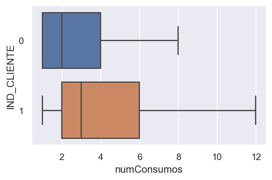

```python
plt.figure(figsize=(5,3))
sns.boxplot(data=consolidacion.toPandas(), x="numConsumos", y="IND_CLIENTE", showfliers = True)
plt.show()
```

Se añaden estas columnas a la entidad usuarios y se comprueba que todos los consumos son anteriores o del mismo dia que FEC_CLIENTE:

```python
consolidacion.where("IND_CLIENTE == '1'").where("maxFechaConsumo > FEC_CLIENTE").toPandas()
```

|  | IDUSUARIO | TIPOUSUARIO | FEC_REGISTRO | CANAL_REGISTRO | IND_CLIENTE | BONDAD_EMAIL | USU_TIPO | FEC_CLIENTE | BONDAD_EMAIL_SIMP | maxFechaConsumo | numConsumos |
| --- | --- | --- | --- | --- | --- | --- | --- | --- | --- | --- | --- |

Queda comprobado que todos los consumos están dentro del rango de estudio.

Seguidamente, se añade la información de la entidad de sesiones. En este caso, como agregación, se obtiene la media de sesiones diarias (se utiliza la media para no crear outliers con los usuarios que inician sesión durante un mayor número de días) y la última fecha de sesión por usuario. Esta fecha se utilizará para hacer un feature engineering inicial.

```python
sesiones.limit(5).toPandas()
```

|  | IDUSUARIO | FECHA_SESION | SESIONES | IND_CLIENTE |
| --- | --- | --- | --- | --- |
| 0 | 6868841 | 2018-01-01 | 11.0 | 0 |
| 1 | 6868844 | 2018-01-01 | 4.0 | 0 |
| 2 | 6868850 | 2018-01-01 | 4.0 | 0 |
| 3 | 6868859 | 2018-01-01 | 3.0 | 0 |
| 4 | 6868859 | 2018-07-09 | 1.0 | 0 |

```python
sesionesAgregacion = sesiones.groupBy("IDUSUARIO").agg(max("FECHA_SESION").alias("maxFechaSesion"),\
                                                       avg("SESIONES").alias("numSesiones"))
consolidacion = consolidacion.join(sesionesAgregacion, "IDUSUARIO", "left")
```

Se guarda el dataframe de sesionesAgregación para utilizarlo en posteriores ciclos.

```python
sesionesAgregacion.toPandas().to_parquet("/Archivos/sesionesPostAgregacion.parquet")
```

Se muestra todo el conjunto de atributos después de aplicar los dos joins a la tabla de usuarios:

```python
consolidacion.limit(5).toPandas()
```

|  | IDUSUARIO | TIPOUSUARIO | FEC_REGISTRO | CANAL_REGISTRO | IND_CLIENTE | BONDAD_EMAIL | USU_TIPO | FEC_CLIENTE | BONDAD_EMAIL_SIMP | maxFechaConsumo | numConsumos | maxFechaSesion | numSesiones |
| --- | --- | --- | --- | --- | --- | --- | --- | --- | --- | --- | --- | --- | --- |
| 0 | 7678334 | PJ | 2019-03-19 | 7 | 0 | 20 | EMPRESARIO INDIVIDUAL | None | 1.0 | 2019-03-19 | 2.0 | 2019-03-19 | 4.0 |
| 1 | 7663760 | PJ | 2019-03-12 | 2 | 0 | 20 | EMPRESARIO INDIVIDUAL | None | 1.0 | 2019-03-12 | 1.0 | 2019-03-12 | 4.0 |
| 2 | 7739515 | PF | 2019-04-22 | 1 | 0 | 20 | None | None | 1.0 | 2019-04-22 | 2.0 | 2019-04-22 | 4.0 |
| 3 | 7619575 | PF | 2019-02-28 | 8 | 0 | 20 | None | None | 1.0 | 2019-02-28 | 2.0 | 2019-02-28 | 4.0 |
| 4 | 7741629 | PF | 2019-04-23 | 6 | 0 | 20 | None | None | 1.0 | 2019-04-23 | 2.0 | 2019-04-23 | 4.0 |

### Feature engineering

Una vez se tienen todas las variables en un mismo dataframe, se aplica feature engineering para obtener información de las variables de fecha. Se probarán estas variables para comprobar si son relevantes.

- **diasParaUltimoConsumo**: De maxFechaConsumo se creará una columna que cuente los días desde la fecha de registro hasta el último consumo.
- **diasParaUltimaSesion**: De maxFechaSesion se aplicará la misma lógica anterior para obtener el número de días hasta la última sesión.
- **diasParaFinal**: De FEC_CLIENTE se obtendrá una nueva variable que cuente los días entre la fecha de registro y esta fecha. Como para los usuarios que no son clientes tienen un valor nulo en esta variable, se pueden aplicar diversas estrategias. En el estudio de Nygard et al. (2020), anteriormente citado en el apartado del estado del arte, se fijan estos nulos como la última fecha que el usuario tiene actividad o, como otra posibilidad, se asigna la última fecha de todo el dataset. Para este estudio, se asigna la estrategia que presenta mejores resultados en el informe, que es la de asignar la última fecha con actividad del usuario.

```python
consolidacion = consolidacion.withColumn("diasParaUltimoConsumo", datediff(col("maxFechaConsumo"),col("FEC_REGISTRO")))
consolidacion = consolidacion.withColumn("diasParaUltimaSesion", datediff(col("maxFechaSesion"),col("FEC_REGISTRO")))
# se rellenan los nulos
consolidacion = consolidacion.withColumn("FEC_CLIENTE", when(col("FEC_CLIENTE").isNull(),col("maxFechaSesion")).otherwise(col("FEC_CLIENTE")))
consolidacion = consolidacion.withColumn("diasParaFinal", datediff(col("FEC_CLIENTE"),col("FEC_REGISTRO")))
```

Se selecciona las columnas interesantes, IDUSUARIO se mantiene para poder cruzar el dato en posteriores ciclos:

```python
consolidacion = consolidacion.select("IDUSUARIO","IND_CLIENTE","TIPOUSUARIO","CANAL_REGISTRO",
                                     "BONDAD_EMAIL_SIMP","numConsumos","numSesiones","diasParaUltimoConsumo",
                                     "diasParaUltimaSesion","diasParaFinal")
```

Se comprueba el dataframe:

```python
consolidacion.toPandas().info(memory_usage=False)
```

```
<class 'pandas.core.frame.DataFrame'>
RangeIndex: 142730 entries, 0 to 142729
Data columns (total 10 columns):
 #   Column                 Non-Null Count   Dtype
---  ------                 --------------   -----
 0   IDUSUARIO              142730 non-null  object
 1   IND_CLIENTE            142730 non-null  object
 2   TIPOUSUARIO            142730 non-null  object
 3   CANAL_REGISTRO         142730 non-null  object
 4   BONDAD_EMAIL_SIMP      142730 non-null  float64
 5   numConsumos            142588 non-null  float64
 6   numSesiones            142730 non-null  float64
 7   diasParaUltimoConsumo  142588 non-null  float64
 8   diasParaUltimaSesion   142730 non-null  int32
 9   diasParaFinal          142730 non-null  int32
dtypes: float64(4), int32(2), object(4)
```

Se detecta que hay usuarios que no han consumido ningun producto y por eso hay valores vacíos en dos de las nuevas variables agregadas. Se asigna un valor de cero para estos nulos.

```python
consolidacion = consolidacion.withColumn("numConsumos", when(col("numConsumos").isNull(), 0).otherwise(col("numConsumos")))
consolidacion = consolidacion.withColumn("diasParaUltimoConsumo", when(col("diasParaUltimoConsumo").isNull(), 0).otherwise(col("diasParaUltimoConsumo")))
```

```python
consolidacion.limit(5).toPandas()
```

|  | IDUSUARIO | IND_CLIENTE | TIPOUSUARIO | CANAL_REGISTRO | BONDAD_EMAIL_SIMP | numConsumos | numSesiones | diasParaUltimoConsumo | diasParaUltimaSesion | diasParaFinal |
| --- | --- | --- | --- | --- | --- | --- | --- | --- | --- | --- |
| 0 | 7678334 | 0 | PJ | 7 | 1.0 | 2.0 | 4.0 | 0 | 0 | 0 |
| 1 | 7663760 | 0 | PJ | 2 | 1.0 | 1.0 | 4.0 | 0 | 0 | 0 |
| 2 | 7739515 | 0 | PF | 1 | 1.0 | 2.0 | 4.0 | 0 | 0 | 0 |
| 3 | 7619575 | 0 | PF | 8 | 1.0 | 2.0 | 4.0 | 0 | 0 | 0 |
| 4 | 7741629 | 0 | PF | 6 | 1.0 | 2.0 | 4.0 | 0 | 0 | 0 |

Para las nuevas columnas relacionadas con la fecha, se tienen muchos outliers como se puede observar a continuación:

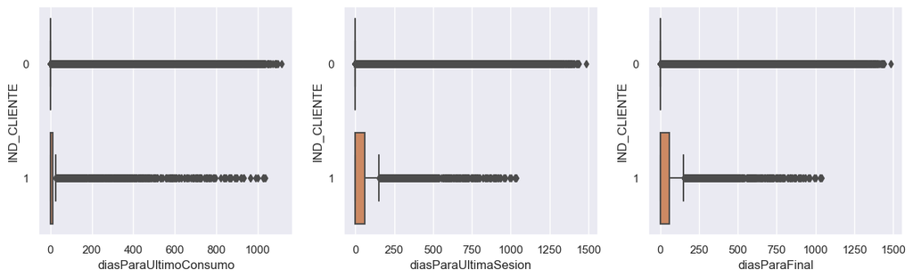

```python
fig, axs = plt.subplots(1,3,figsize=(15,4))
sns.set(style='darkgrid')
sns.boxplot(data=consolidacion.toPandas(), x="diasParaUltimoConsumo", y="IND_CLIENTE", showfliers = True, ax=axs[0])
sns.boxplot(data=consolidacion.toPandas(), x="diasParaUltimaSesion", y="IND_CLIENTE", showfliers = True, ax=axs[1])
sns.boxplot(data=consolidacion.toPandas(), x="diasParaFinal", y="IND_CLIENTE", showfliers = True, ax=axs[2])
plt.show()
```

Para el subgrupo de no clientes se encuentra que el grueso de la población está en el cero (únicamente los outliers están en puntos alejados del cero). La explicación más plausible es que la o el usuario se registre en la plataforma y únicamente tenga actividad el dia del registro. Este comportamiento puede ser normal, ya que una persona se puede registrar para ver qué ofrece la página web, consume algún producto gratuito y no vuelve a iniciar sesión en dias posteriores. En contraste, se identifica claramente que los que acaban siendo clientes tienen actividad en dias posteriores, esto refleja que estan interesados en los servicios ofrecidos.

Se aplica reducción de outliers como con numConsumos y numSesiones:

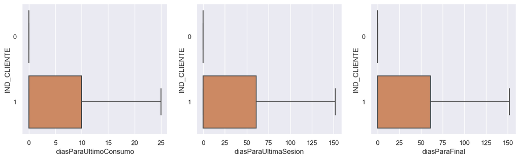

```python
consolidacion = outliersToMaxWhisker(consolidacion, "diasParaUltimoConsumo")
consolidacion = outliersToMaxWhisker(consolidacion, "diasParaUltimaSesion")
consolidacion = outliersToMaxWhisker(consolidacion, "diasParaFinal")

fig, axs = plt.subplots(1,3,figsize=(15,4))
sns.set(style='darkgrid')
sns.boxplot(data=consolidacion.toPandas(), x="diasParaUltimoConsumo", y="IND_CLIENTE", showfliers = True, ax=axs[0])
sns.boxplot(data=consolidacion.toPandas(), x="diasParaUltimaSesion", y="IND_CLIENTE", showfliers = True, ax=axs[1])
sns.boxplot(data=consolidacion.toPandas(), x="diasParaFinal", y="IND_CLIENTE", showfliers = True, ax=axs[2])
plt.show()
```

Se puede observar que el dato de diasParaUltimaSesion y diasParaFinal es casi idéntico. Esto podría significar que para el grueso de los clientes, la última fecha de sesión es el dia en que el usuario compró algún producto. En pasos posteriores se estudiará esta correlación.

Por otro lado, en la población de clientes se puede observar que inician sesión durante días y además consumen productos gratuitos no únicamente el día del registro, si no a lo largo del tiempo. Esta información puede estar explicando que estos usuarios van investigando la información que les parece relevante hasta que deciden comprar.

## Preparación del dataset

Una vez se tiene un dataset consolidado, se tiene que transformar sus variables categóricas en columnas binarias, se tiene que normalizar o escalar las variables numéricas y se tienen que aplicar tests estadísticos para mantener los atributos estadísticamente relevantes.

### One-hot-encoding

Se crea una función que hará one-hot-encoding de las variables que se incluyan:

```python
from sklearn.preprocessing import OneHotEncoder

def oneHotEncoding(dataRaw,columnName):
    """Función que transforma una variable categórica con one-hot-encoding, elimina la original
       y cambia el nombre de las nuevas columnas a un formato descriptivo """

    OHencoder = OneHotEncoder(sparse_output=False)
    # creación de nuevas columnas binarias
    columnDataEncoded = pd.DataFrame(OHencoder.fit_transform(dataRaw[[columnName]]))
    # cambio de nombre de las nuevas columnas para que sea más descriptivo
    columnDataEncoded.columns = OHencoder.get_feature_names_out([columnName])
    # añadido de las nuevas columnas al dataframe original menos la columna transformada
    dataTransformed = pd.concat([dataRaw.drop([columnName], axis=1), columnDataEncoded], axis=1)
    return dataTransformed
```

Transformación de las dos variables categóricas disponibles en one-hot-encoding, cambiando el tipo de las dos últimas columnas. El atributo TIPOUSUARIO tiene tres posibilidades, persona física, jurídica o indeterminada, por lo que no se ha creado una variable binaria a partir de las tres y se ha optado por la opción de separarlas en tres columnas diferentes.

```python
consolidacion = consolidacion.toPandas()

consolidacion = oneHotEncoding(consolidacion, 'CANAL_REGISTRO')
consolidacion = oneHotEncoding(consolidacion, 'TIPOUSUARIO')
```

```python
consolidacion.info(memory_usage=False)
```

```
<class 'pandas.core.frame.DataFrame'>
RangeIndex: 142730 entries, 0 to 142729
Data columns (total 19 columns):
 #   Column                 Non-Null Count   Dtype
---  ------                 --------------   -----
 0   IDUSUARIO              142730 non-null  object
 1   IND_CLIENTE            142730 non-null  object
 2   BONDAD_EMAIL_SIMP      142730 non-null  float64
 3   numConsumos            142730 non-null  float64
 4   numSesiones            142730 non-null  float64
 5   diasParaUltimoConsumo  142730 non-null  float64
 6   diasParaUltimaSesion   142730 non-null  float64
 7   diasParaFinal          142730 non-null  float64
 8   CANAL_REGISTRO_1       142730 non-null  float64
 9   CANAL_REGISTRO_2       142730 non-null  float64
 10  CANAL_REGISTRO_3       142730 non-null  float64
 11  CANAL_REGISTRO_4       142730 non-null  float64
 12  CANAL_REGISTRO_6       142730 non-null  float64
 13  CANAL_REGISTRO_7       142730 non-null  float64
 14  CANAL_REGISTRO_8       142730 non-null  float64
 15  CANAL_REGISTRO_9       142730 non-null  float64
 16  TIPOUSUARIO_PF         142730 non-null  float64
 17  TIPOUSUARIO_PJ         142730 non-null  float64
 18  TIPOUSUARIO_PX         142730 non-null  float64
dtypes: float64(17), object(2)
```

### Tests estadísticos

Se aplican test estadísticos para mantener únicamente los atributos relevantes para predecir la variable objetivo, se crea una función que aplique el test y muestre visualmente por pantalla los resultados.

```python
from sklearn.feature_selection import chi2, SelectKBest, f_classif

def applyTest(data, columns, target, test, mode):
    """Esta función utiliza la función SelectKBest de sklearn para obtener los estadísticos dependiendo
       del test que se quiera aplicar y visualizarlos. En caso de querer obtener los mejores atributos
       se puede utilizar la variable 'mode' que para se devuelvan los top K atributos."""

    X = data[columns]
    if test == chi2:
        Y = data[[target]]
    if test == f_classif:
        Y = data[[target]].values.ravel()

    computeTest = SelectKBest(test, k = mode)
    results = computeTest.fit(X,Y)

    # visualización del p_value y el estadistico que devuelve la función dependiendo del test
    fig, axs = plt.subplots(1,2,figsize=(12,3))
    sns.barplot(x=results.feature_names_in_,y=results.pvalues_, color="steelblue", ax=axs[0]).set_title("pvalue")
    if test == chi2:

        axs[0].axhline(0.05,color='cornflowerblue',linestyle='dashed')

    sns.barplot(x=results.feature_names_in_,y=results.scores_, color="steelblue", ax=axs[1]).set_title("score")

    for ax in fig.axes:
        plt.sca(ax)
        plt.xticks(rotation=45, horizontalalignment="right")

    plt.show()

    return None
```

Se utiliza el test de Chi cuadrado para reducir dimensionalidad, para mantener únicamente las variables categóricas codificadas más relevantes:

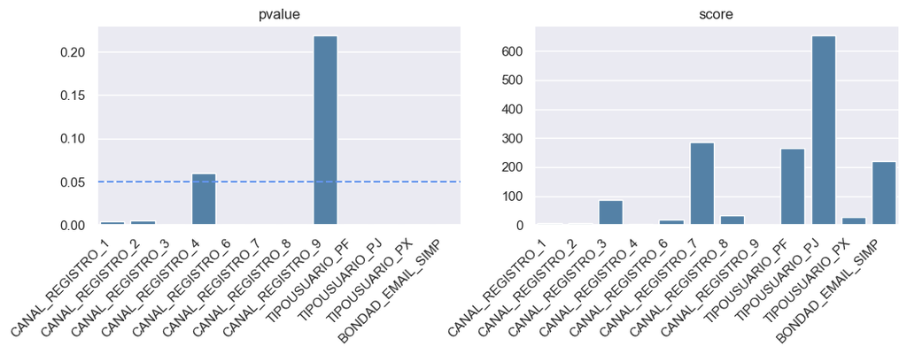

```python
columns = ["CANAL_REGISTRO_1","CANAL_REGISTRO_2","CANAL_REGISTRO_3","CANAL_REGISTRO_4","CANAL_REGISTRO_6",\
           "CANAL_REGISTRO_7","CANAL_REGISTRO_8","CANAL_REGISTRO_9","TIPOUSUARIO_PF","TIPOUSUARIO_PJ","TIPOUSUARIO_PX",\
           "BONDAD_EMAIL_SIMP"]

applyTest(consolidacion, columns, "IND_CLIENTE", chi2, "all")
```

Se observa que, de las 12 variables categóricas, 5 de ellas tienen una gran correlación con la variable target (gráfico de la derecha) y únicamente dos variables son estadísticamente independientes con IND_CLIENTE, ya que el valor del pvalue es superior a 0.05 (gráfico de la izquierda). Este resultado va en línea con los gráficos exploratorios por subgrupos de pasos anteriores, donde no se veían diferencias relevantes en los directorios 4 y 9.

Debido a este resultado, se eliminan estos dos atributos.

```python
consolidacion = consolidacion.drop(columns=["CANAL_REGISTRO_4","CANAL_REGISTRO_9"])
```

Antes de aplicar el test ANOVA a las variables numéricas con la variable objetivo, se va a aplicar el test de Pearson de la libreria Pandas para encontrar la correlación entre las variables numéricas, para descartar que dos variables estén completamente correlacionadas.

```python
def checkCorrelation(data, columns):
    """Esta funcion muestra gráficamente la correlación entre variables numéricas."""

    X = data[columns]

    plt.figure(figsize=(5,3))
    sns.heatmap(X.corr(),annot=True)
    plt.xticks(rotation=45, horizontalalignment="right")
    plt.show()
```

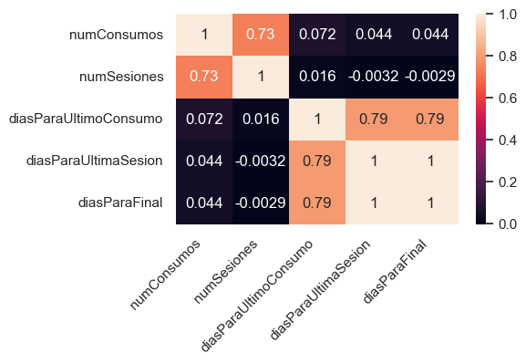

```python
columns = ["numConsumos","numSesiones","diasParaUltimoConsumo","diasParaUltimaSesion","diasParaFinal"]
checkCorrelation(consolidacion, columns)
```

Se observa que las tres variables nuevas relacionadas con la fecha estan correlacionadas entre ellas. Efectivamente, diasParaFinal está completamente relacionado con el atributo 'diasParaUltimaSesion', debido a que la fecha de conversión a cliente será también la última fecha de sesión, por lo que este atributo será eliminado. Se comprueba que hay una correlación entre número de consumos y número de sesiones, junto con las dos variables análogas referentes a los días. Puede tener sentido ya que contra más consumos se consuman, más sesiones se dedicarán a leer los datos, búsqueda de nuevos productos, entre otros. Este doble par de atributos se mantendrán para observar el efecto en los modelos.

Se elimina la variable descartada diasParaFinal:

```python
consolidacion = consolidacion.drop(columns=["diasParaFinal"])
```

Se aplica el test ANOVA a estas variables junto con la variable objetivo:

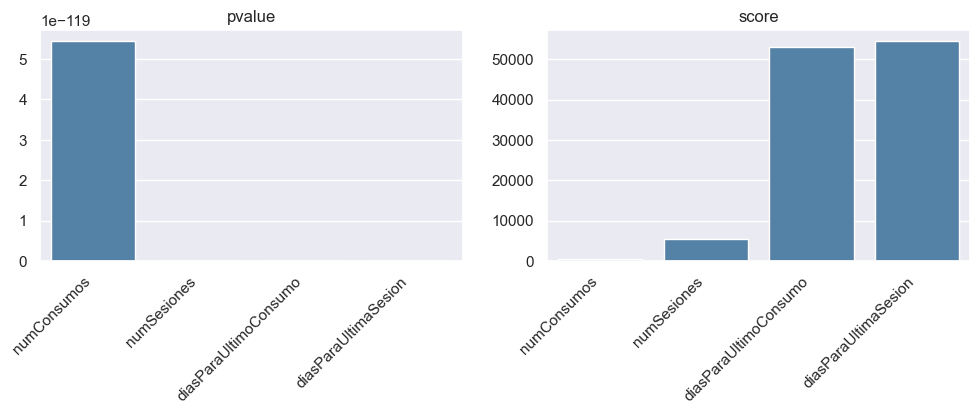

```python
columns = ["numConsumos","numSesiones","diasParaUltimoConsumo","diasParaUltimaSesion"]

applyTest(consolidacion, columns, "IND_CLIENTE", f_classif, "all")
```

Como se puede observar, el valor F nos indica la diferencia o separación entre las medias de los dos subgrupos de cada variable a partir de la variable objetivo. Los mayores valores los encontramos en los atributos de los días, esto es normal ya que cuando se vió el tratamiento de los outliers por grupos, la población de los no clientes estaba asentada en el cero y en los clientes en un rango. Seguidamente, el mayor valor lo encontramos en 'numSesiones' y el menor de todos es numConsumos. Para visualizar si todos son estadísticamente revelantes, podemos observar que el pvalue de todos es menor a 0.05, por lo que todos los atributos se mantendrán (menos en numConsumos, el pvalue de todos los demás atributos es tan pequeño que a efectos prácticos es un cero).

Antes de escribir el dato en un parquet para su posterior ingesta en los modelos, se escalan las variables numéricas:

```python
from sklearn.preprocessing import MinMaxScaler
scaler = MinMaxScaler()
consolidacion[columns] = scaler.fit_transform(consolidacion[columns])
```

Muestra del conjunto de datos final:

```python
consolidacion
```

|  | IDUSUARIO | IND_CLIENTE | BONDAD_EMAIL_SIMP | numConsumos | numSesiones | diasParaUltimoConsumo | diasParaUltimaSesion | CANAL_REGISTRO_1 | CANAL_REGISTRO_2 | CANAL_REGISTRO_3 | CANAL_REGISTRO_6 | CANAL_REGISTRO_7 | CANAL_REGISTRO_8 | TIPOUSUARIO_PF | TIPOUSUARIO_PJ | TIPOUSUARIO_PX |
| --- | --- | --- | --- | --- | --- | --- | --- | --- | --- | --- | --- | --- | --- | --- | --- | --- |
| 0 | 7678334 | 0 | 1.0 | 0.166667 | 0.130435 | 0.0 | 0.0 | 0.0 | 0.0 | 0.0 | 0.0 | 1.0 | 0.0 | 0.0 | 1.0 | 0.0 |
| 1 | 7663760 | 0 | 1.0 | 0.083333 | 0.130435 | 0.0 | 0.0 | 0.0 | 1.0 | 0.0 | 0.0 | 0.0 | 0.0 | 0.0 | 1.0 | 0.0 |
| 2 | 7739515 | 0 | 1.0 | 0.166667 | 0.130435 | 0.0 | 0.0 | 1.0 | 0.0 | 0.0 | 0.0 | 0.0 | 0.0 | 1.0 | 0.0 | 0.0 |
| 3 | 7619575 | 0 | 1.0 | 0.166667 | 0.130435 | 0.0 | 0.0 | 0.0 | 0.0 | 0.0 | 0.0 | 0.0 | 1.0 | 1.0 | 0.0 | 0.0 |
| 4 | 7741629 | 0 | 1.0 | 0.166667 | 0.130435 | 0.0 | 0.0 | 0.0 | 0.0 | 0.0 | 1.0 | 0.0 | 0.0 | 1.0 | 0.0 | 0.0 |
| ... | ... | ... | ... | ... | ... | ... | ... | ... | ... | ... | ... | ... | ... | ... | ... | ... |
| 142725 | 7691634 | 0 | 0.0 | 0.666667 | 0.434783 | 0.0 | 0.0 | 1.0 | 0.0 | 0.0 | 0.0 | 0.0 | 0.0 | 1.0 | 0.0 | 0.0 |
| 142726 | 7788284 | 0 | 1.0 | 0.666667 | 0.434783 | 0.0 | 0.0 | 1.0 | 0.0 | 0.0 | 0.0 | 0.0 | 0.0 | 1.0 | 0.0 | 0.0 |
| 142727 | 8129509 | 0 | 0.0 | 0.666667 | 0.434783 | 0.0 | 0.0 | 0.0 | 0.0 | 0.0 | 0.0 | 0.0 | 0.0 | 1.0 | 0.0 | 0.0 |
| 142728 | 7249967 | 0 | 0.0 | 0.666667 | 0.434783 | 0.0 | 0.0 | 1.0 | 0.0 | 0.0 | 0.0 | 0.0 | 0.0 | 1.0 | 0.0 | 0.0 |
| 142729 | 7920223 | 0 | 0.0 | 0.666667 | 0.434783 | 0.0 | 0.0 | 1.0 | 0.0 | 0.0 | 0.0 | 0.0 | 0.0 | 1.0 | 0.0 | 0.0 |

142730 rows × 16 columns

Escritura en un archivo con los datos limpios

```python
consolidacion.to_parquet("/Archivos/consolidacion.parquet")
```